# Modelowanie i detekcja oszustw finansowych w transakcjach elektronicznych przy użyciu metod uczenia maszynowego

Adam Wróbel

2025-06-01

# Wybór zbioru danych

Do projektu wybrano zbiór danych dotyczący wykrywania oszustw finansowych w transakcjach, zawierający informacje o 50 000 unikalnych transakcjach. Dane obejmują różnorodne cechy związane z transakcją, takie jak kwota, typ transakcji, lokalizacja, urządzenie użyte do przeprowadzenia transakcji oraz informacje o użytkowniku, w tym historię poprzednich oszustw i ocenę ryzyka. Zbiór ten zawiera zarówno dane numeryczne, jak i kategoryczne oraz zmienne czasowe, co umożliwia budowę zaawansowanych modeli predykcyjnych do rozróżniania transakcji uczciwych od oszustw.

Źródło danych: Samay Ashar, Fraud Detection Transactions Dataset, Kaggle, https://www.kaggle.com/datasets/samayashar/fraud-detection-transactions-dataset

# Zdefiniowanie problemu

Celem projektu jest zbudowanie modelu predykcyjnego, który będzie skutecznie klasyfikował transakcje finansowe jako oszukańcze (fraud) lub uczciwe (non-fraud) na podstawie dostępnych cech opisujących transakcję oraz użytkownika. Problem ma charakter klasyfikacji binarnej i wiąże się z koniecznością wykrycia rzadkich, ale istotnych przypadków oszustw, które mogą prowadzić do znaczących strat finansowych.

# Charakterystyka zmiennych w zbiorze danych

### 1. Identyfikatory i dane użytkownika

- **Transaction_ID**  
  Unikalny identyfikator transakcji.
- **User_ID**  
  Unikalny identyfikator użytkownika dokonującego transakcji.

### 2. Dane dotyczące transakcji

- **Transaction_Amount**  
  Kwota pieniężna transakcji.
- **Transaction_Type**  
  Typ transakcji: POS, Bank Transfer, Online, ATM Withdrawal.
- **Timestamp**  
  Data i godzina wykonania transakcji.
- **Account_Balance**  
  Saldo konta użytkownika przed transakcją.
- **Transaction_Distance**  
  Odległość między typową lokalizacją użytkownika a miejscem wykonania transakcji.
- **Is_Weekend**  
  Wskaźnik informujący, czy transakcja miała miejsce w weekend (0 = nie, 1 = tak).

### 4. Dane o sprzedawcy i metodach płatności

- **Merchant_Category**  
  Kategoria sprzedawcy, Travel, Clothing, Restaurants, Electronics, Groceries.
- **Card_Type**  
  Typ karty płatniczej użytej do transakcji (Amex, Mastercar, Visa, Discover).
- **Card_Age**  
  Wiek karty w miesiącach.
- **Authentication_Method**  
  Metoda uwierzytelnienia użytkownika (Biometric, Password, OTP, PIN).

### 5. Historie i statystyki transakcji użytkownika

- **Previous_Fraudulent_Activity**  
  Liczba poprzednich oszukańczych aktywności użytkownika.
- **Daily_Transaction_Count**  
  Liczba transakcji użytkownika dokonanych w danym dniu.
- **Avg_Transaction_Amount_7d**  
  Średnia kwota transakcji użytkownika z ostatnich 7 dni.
- **Failed_Transaction_Count_7d**  
  Liczba nieudanych transakcji w ciągu ostatnich 7 dni.
- **Risk_Score**  
  Obliczony wskaźnik ryzyka dla danej transakcji.

### 6. Zmienna docelowa

- **Fraud_Label**  
  Zmienna binarna wskazująca, czy transakcja jest oszukańcza:  
  0 = non-fraud (uczciwa)  
  1 = fraud (oszukańcza)

# Usunięcie zmiennych i czyszczenie braków

Na etapie wstępnej analizy danych zidentyfikowano brakujące wartości w niektórych zmiennych opisujących transakcje. Braki te zostały usunięte w zależności od charakteru zmiennej oraz wpływu na proces modelowania.

Ze zbioru danych usunięto zmienne **Transaction_ID** oraz **User_ID**. Zmienne te pełnią wyłącznie funkcję identyfikacyjną i nie wnoszą wartości informacyjnej do procesu predykcji zmiennej docelowej Fraud_Label. Pozostawienie ich w zbiorze mogłoby prowadzić do przeuczenia modelu lub generowania nieistotnych wzorców, dlatego zostały one wykluczone z dalszej analizy.

# Przetwarzanie zmiennej czasowej

W celu wzbogacenia zbioru danych o dodatkowe informacje czasowe, dokonano transformacji zmiennej **Timestamp**, zawierającej datę i godzinę wykonania transakcji. Oryginalną zmienną przekształcono do formatu daty i czasu (`POSIXct`), a następnie wyodrębniono z niej następujące cechy:

- **DayOfWeek** – dzień tygodnia wykonania transakcji (wartości od 1 do 7, gdzie 1 oznacza poniedziałek, a 7 niedzielę),
- **Month** – miesiąc wykonania transakcji (wartości od 1 do 12),
- **TimeInterval** – przedział godzinowy, w którym dokonano transakcji:
  - `00:01–06:00` – noc,
  - `06:01–12:00` – poranek,
  - `12:01–18:00` – popołudnie,
  - `18:01–00:00` – wieczór.

Powyższe zmienne zostały dodane do zbioru danych w celu lepszego uchwycenia ewentualnych wzorców czasowych charakterystycznych dla transakcji oszukańczych. Następnie oryginalna zmienna **Timestamp** została usunięta, ponieważ jej szczegółowy format nie był już potrzebny w dalszej analizie.

Dzięki tej transformacji możliwe jest m.in. badanie rozkładu transakcji w poszczególnych porach dnia, dniach tygodnia czy miesiącach, co może mieć istotne znaczenie w procesie wykrywania nadużyć finansowych.

# Sprawdzanie zbalansowania zmiennej Fraud_Label

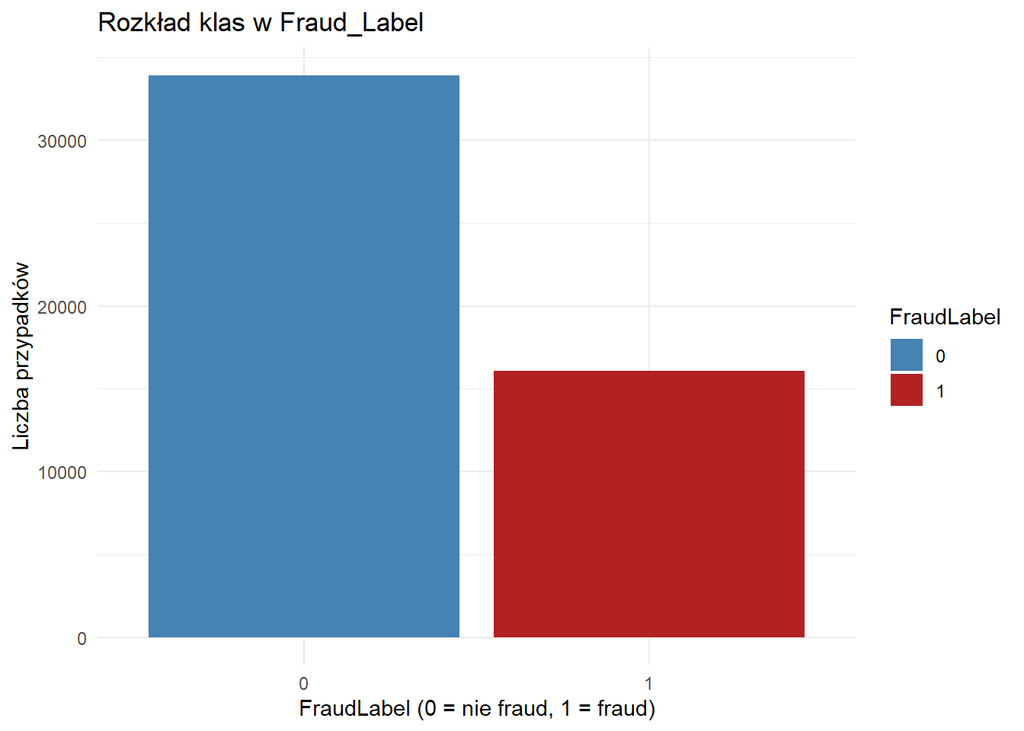

Analiza zmiennej objaśnianej **Fraud_Label**, która przyjmuje wartości `0` (transakcja nieoszukańcza) oraz `1` (transakcja oszukańcza), wykazała znaczną nierównowagę klas. W zbiorze danych znajduje się:

- **16 067 obserwacji klasy “fraud” (oszustwo)**,
- **33 933 obserwacje klasy “non-fraud” (brak oszustwa)**.

Oznacza to, że przypadki oszustw stanowią jedynie około **32% wszystkich transakcji**, natomiast transakcje nieoszukańcze dominują w zbiorze, stanowiąc około **68% danych**.

Taka dysproporcja może negatywnie wpłynąć na działanie klasyfikatorów, powodując ich tendencję do preferowania przewidywania klasy większościowej. W związku z tym, na etapie modelowania rozważyłem zastosowanie metod radzenia sobie z niezbalansowanymi danymi, takich jak:

- oversampling klasy mniejszościowej (np. technika SMOTE),
- undersampling klasy większościowej.

# Transformacja zmiennych kategorycznych

Przekształcenie tych zmiennych do typu **factor** było niezbędne z kilku powodów:

- poprawne rozpoznanie zmiennych kategorycznych przez algorytmy uczenia maszynowego,
- umożliwienie prawidłowego zastosowania metod kodowania zmiennych (np. one-hot encoding),
- zmniejszenie ryzyka błędnej interpretacji zmiennych liczbowych jako ilościowych, co mogłoby prowadzić do niepoprawnych wyników modelowania.

# Sprawdzenie współliniowości zmiennych liczbowych

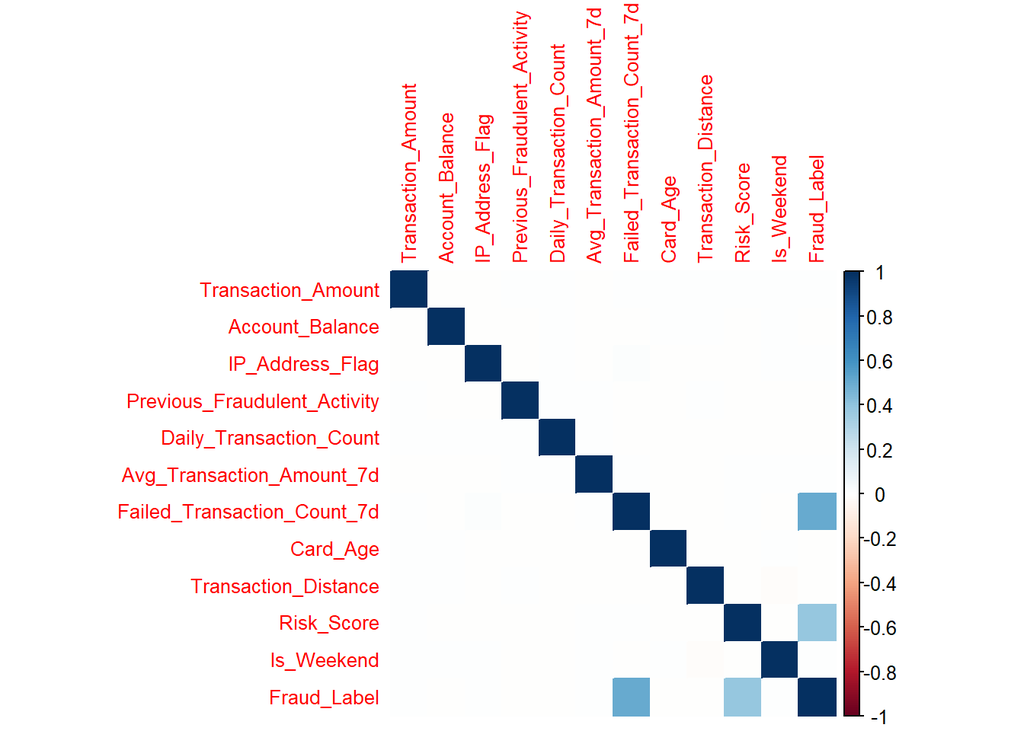

W celu zbadania współliniowości pomiędzy zmiennymi numerycznymi, obliczono macierz korelacji dla tych zmiennych. Analiza wykazała, że zmienna objaśniana **Fraud_Label** jest najsilniej skorelowana z następującymi zmiennymi:

- **Risk_Score** – współczynnik korelacji wynosi **0.39**,
- **Failed_Transaction_Count_7d** – współczynnik korelacji wynosi **0.51**.

Otrzymane wartości wskazują na umiarkowaną dodatnią korelację obu zmiennych z cechą objaśnianą. Może to sugerować, że zarówno ocena ryzyka transakcji (**Risk_Score**), jak i liczba nieudanych prób transakcji w ciągu ostatnich 7 dni (**Failed_Transaction_Count_7d**) mogą być istotnymi predyktorami w modelach klasyfikacyjnych służących do wykrywania transakcji oszukańczych.

Pozostałe zmienne numeryczne wykazały niskie wartości korelacji z cechą objaśnianą, co może oznaczać mniejsze znaczenie tych cech przy predykcji oszustw finansowych.

Macierz korelacji nie ujawniła przypadków bardzo wysokiej współliniowości (r > 0.8) pomiędzy zmiennymi niezależnymi, dlatego nie było konieczności usuwania żadnej z cech w celu uniknięcia problemu wielokolinearności.

# Analiza powiązań zmiennych kategorycznych

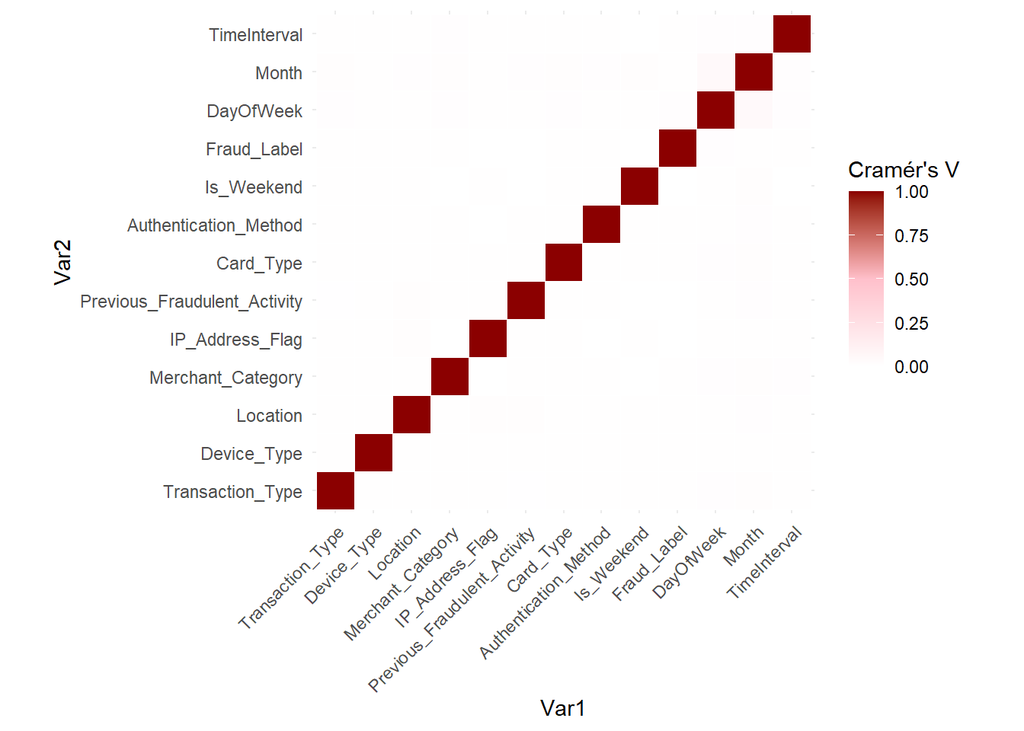

Dla zmiennych kategorycznych przeprowadzono analizę współzależności z wykorzystaniem miary **Cramér’s V**, która pozwala ocenić siłę związku pomiędzy dwiema zmiennymi jakościowymi.

Wyniki analizy wykazały, że nie występują silne zależności między zmiennymi.

Brak silnych związków pomiędzy zmiennymi kategorycznymi pozwala na zachowanie wszystkich tych zmiennych w dalszych etapach modelowania, ponieważ każda z nich może wnosić unikalną wartość informacyjną dla modelu predykcyjnego.

Miara **Cramér’s V** została wykorzystana ze względu na jej uniwersalność w ocenie siły powiązań pomiędzy zmiennymi nominalnymi i porządkowymi.

# Wstępna selekcja cech o niskiej zmienności

```
## character(0)
```

W celu identyfikacji zmiennych o niskiej wartości informacyjnej przeprowadzono analizę zmienności zarówno dla cech liczbowych, jak i kategorycznych:

- Dla zmiennych liczbowych obliczono wariancję. Zmienne o wariancji bliskiej zeru zostałyby uznane za mało informacyjne i potencjalnie usunięte ze zbioru danych.
- Dla zmiennych kategorycznych sprawdzono częstość występowania poszczególnych kategorii. Zmienna była uznawana za mało zróżnicowaną, jeśli jedna z kategorii stanowiła ponad **95% wszystkich obserwacji**.

W analizowanym zbiorze danych **nie wykryto zmiennych spełniających powyższe kryteria niskiej zmienności**, co oznacza, że wszystkie cechy zachowują potencjalną wartość informacyjną i mogą zostać wykorzystane w dalszym etapie modelowania.

# Selekcja cech na podstawie Mutual Information

Mutual Information Scores między zmiennymi a Fraud_Label

|  | Variable | Mi_Score |
| --- | --- | --- |
| Failed_Transaction_Count_7d | Failed_Transaction_Count_7d | 0.28571767 |
| Risk_Score | Risk_Score | 0.19276211 |
| Transaction_Distance | Transaction_Distance | 0.00049837 |
| Transaction_Amount | Transaction_Amount | 0.00037670 |
| Card_Age | Card_Age | 0.00036161 |
| Avg_Transaction_Amount_7d | Avg_Transaction_Amount_7d | 0.00033306 |
| Account_Balance | Account_Balance | 0.00028063 |
| Daily_Transaction_Count | Daily_Transaction_Count | 0.00010078 |
| DayOfWeek | DayOfWeek | 0.00007082 |
| Month | Month | 0.00005152 |
| TimeInterval | TimeInterval | 0.00003954 |
| Authentication_Method | Authentication_Method | 0.00002731 |
| Location | Location | 0.00002621 |
| Merchant_Category | Merchant_Category | 0.00002289 |
| Device_Type | Device_Type | 0.00002163 |
| Card_Type | Card_Type | 0.00002099 |
| Transaction_Type | Transaction_Type | 0.00001252 |
| IP_Address_Flag | IP_Address_Flag | 0.00000457 |
| Previous_Fraudulent_Activity | Previous_Fraudulent_Activity | 0.00000026 |
| Is_Weekend | Is_Weekend | 0.00000000 |

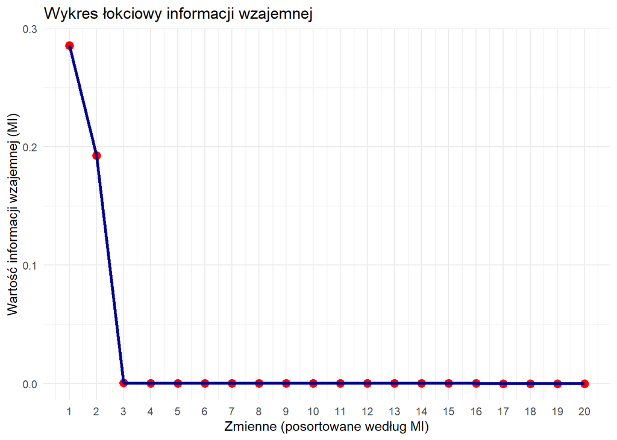

## Selekcja cech na podstawie Mutual Information

W celu określenia siły zależności pomiędzy zmiennymi niezależnymi a zmienną objaśnianą **Fraud_Label**, obliczono wskaźniki **Mutual Information (MI)**. MI mierzy ilość informacji, jaką dana zmienna wnosi o zmiennej celu, bez zakładania liniowej zależności, dzięki czemu jest odpowiednia zarówno dla zmiennych liczbowych, jak i kategorycznych.

Wyniki analizy wskazały, że najwyższe wartości MI osiągnęły następujące zmienne:

- **Failed_Transaction_Count_7d** (0.2857),
- **Risk_Score** (0.1928),
- **Transaction_Distance**, **Transaction_Amount**, **Card_Age** — o znacznie niższych, lecz zauważalnych wartościach MI.

Pozostawione zostały zmienne o wyższych wartościach MI (pierwsze 16 zmiennych), gdyż mogą one w istotny sposób wspierać model w klasyfikacji transakcji jako fraud lub non-fraud.

Zastosowanie Mutual Information umożliwiło zredukowanie liczby cech bez utraty istotnej informacji potrzebnej do predykcji oszustw transakcyjnych.

# Rozkład zmiennych numerycznych względem Fraud_Labels

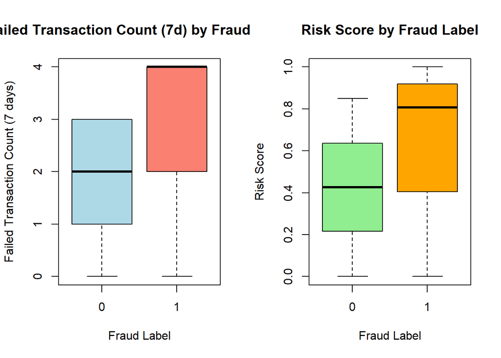

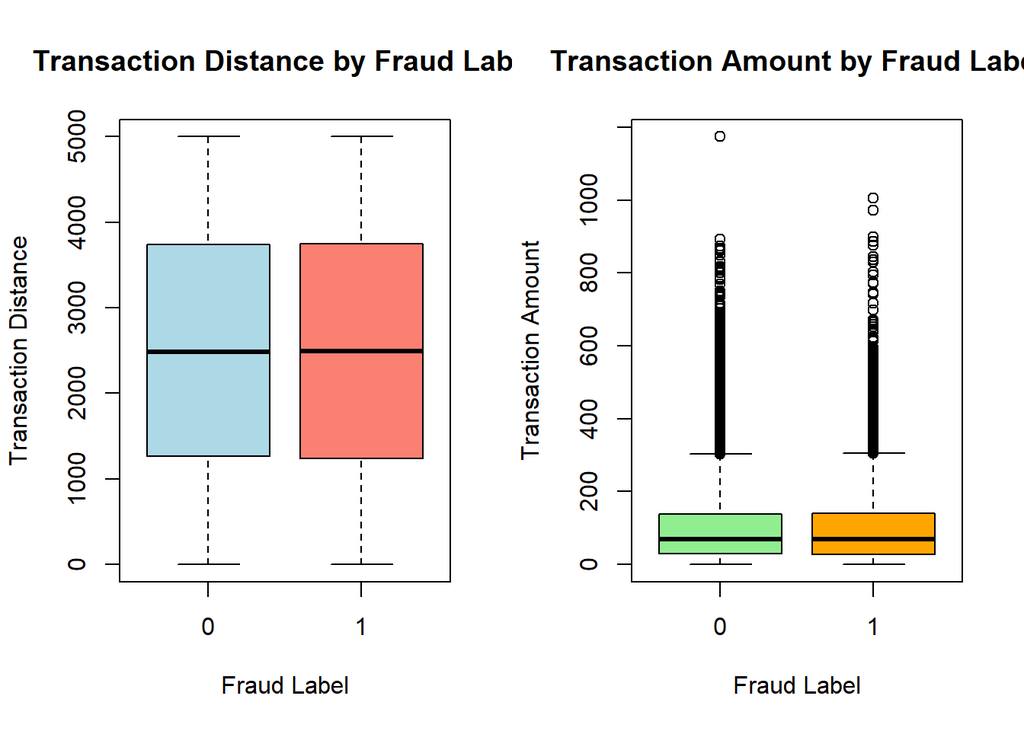

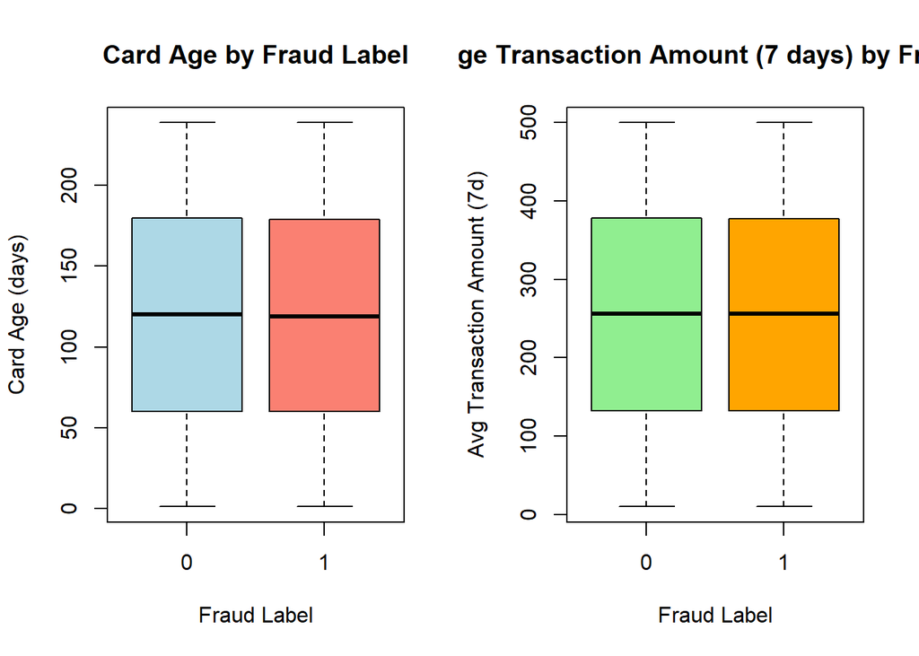

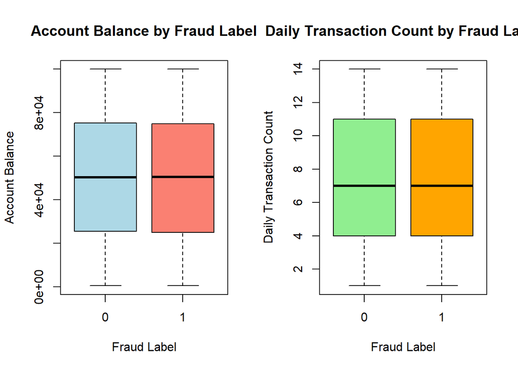

Na podstawie wykresów pudełkowych przeanalizowano różnice w rozkładzie kilku kluczowych zmiennych numerycznych w grupach.

- **Failed Transaction Count (7d)**: Widać wyraźnie, że dla transakcji oznaczonych jako fraud liczba nieudanych transakcji w ciągu ostatnich 7 dni jest zazwyczaj wyższa, co może sugerować zwiększone ryzyko oszustwa powiązane z częstszymi niepowodzeniami.
- **Risk Score**: Również tutaj różnica jest znacząca — transakcje fraudowe mają zdecydowanie wyższe oceny ryzyka, co potwierdza sensowność tego wskaźnika jako predyktora oszustw.

Natomiast dla pozostałych analizowanych zmiennych:

- **Transaction Distance**
- **Transaction Amount**
- **Card Age**
- **Average Transaction Amount (7 days)**
- **Account Balance**
- **Daily Transaction Count**

nie zaobserwowano istotnych różnic w rozkładach między transakcjami fraudowymi a nie-fraudowymi. Oznacza to, że te zmienne mogą mieć ograniczone znaczenie w rozróżnianiu przypadków oszustw w tym zbiorze danych.

# Rozkład zmiennych kategorycznych względem Fraud_Labels

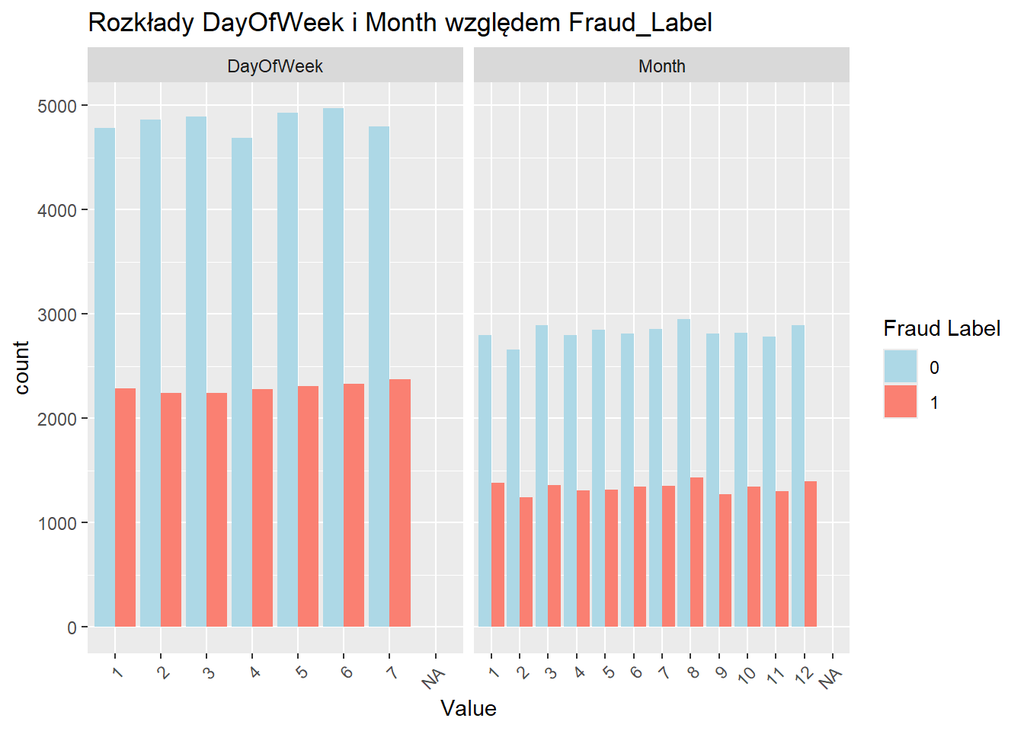

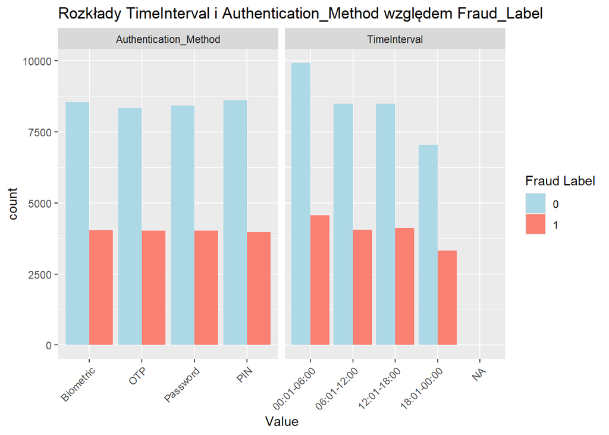

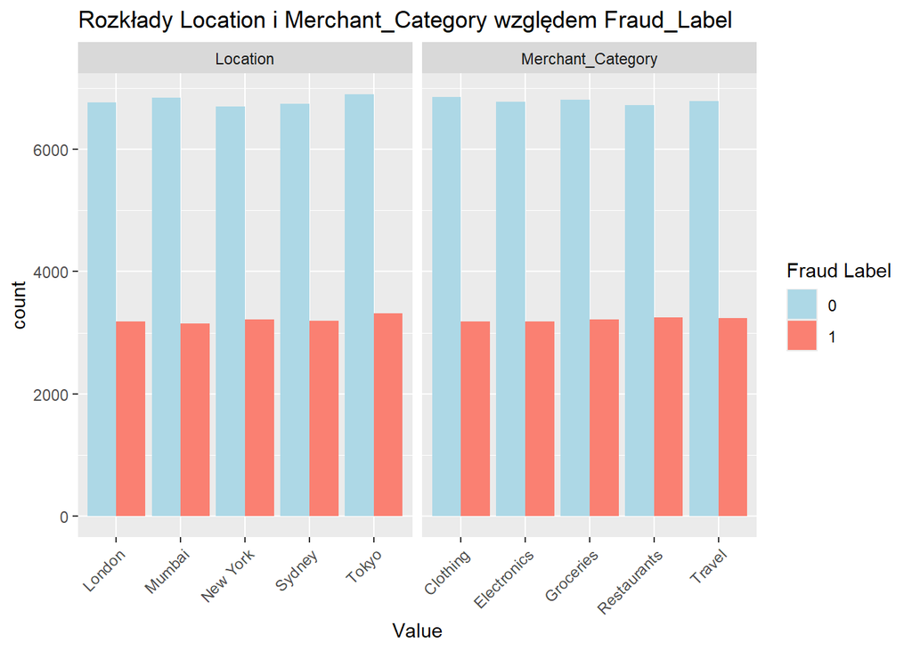

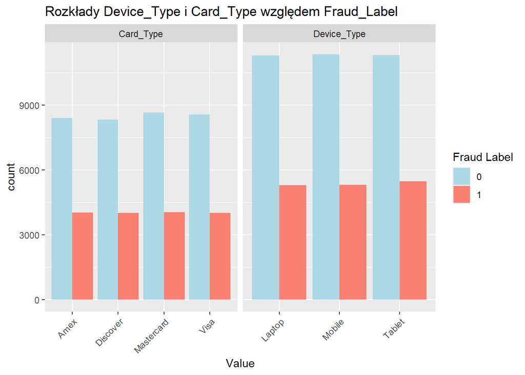

Na podstawie wykresów słupkowych przeanalizowano różnice w rozkładzie kilku kluczowych zmiennych kategorycznych w grupach.

- **TimeInterval**: Widać wyraźnie, że dla transakcji oznaczonych jako fraud liczba transakcji w ciągu doby zmniejsza się. Jest zazwyczaj wyższa rano, co może sugerować zwiększone ryzyko oszustwa w godzinach między północą a porankiem (6:00).

nie zaobserwowano istotnych różnic w rozkładach między transakcjami fraudowymi a nie-fraudowymi. Oznacza to, że te zmienne mogą mieć ograniczone znaczenie w rozróżnianiu przypadków oszustw w tym zbiorze danych.

# Podział zmiennych na zbiory treningowe i testowe

Zbiór danych jest niezbalansowany klasowo, dlatego w celu zachowania rozkładu klas w zbiorach treningowym i testowym zastosowano losowanie warstwowe z użyciem parametru strata. Zbiór danych został podzielony w stosunku 0.8 dla zbioru treningowego i 0.2 dla zbioru testowego.

# Oversampling

W celu wstępnej oceny skuteczności modeli klasyfikacyjnych zastosowano losowo wybraną metodę oversamplingu — SMOTE — w celu zredukowania problemu niezrównoważonych klas. Na tym etapie nie skupiono się na optymalnym doborze techniki balansowania, a jedynie na zapewnieniu porównywalnych warunków dla wszystkich modeli. Szczegółowa analiza i wybór najbardziej efektywnej metody balansowania zostaną przeprowadzone w kolejnych etapach projektu.

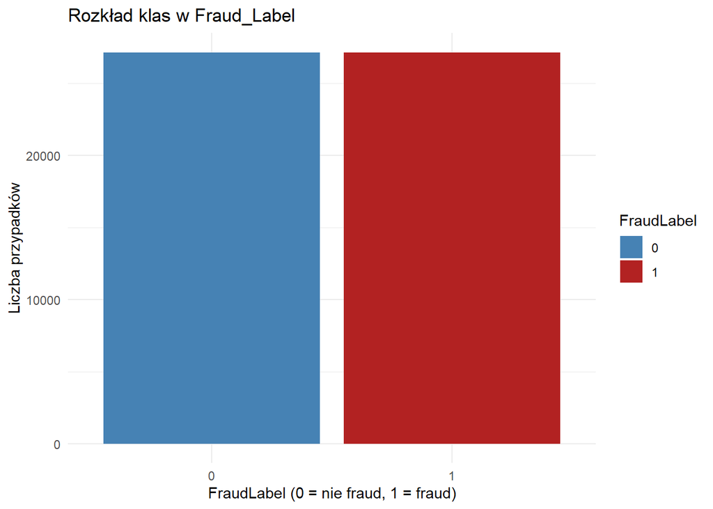

Zbiór treningowy po oversamplingu zawiera zrównoważoną liczbę obserwacji w obu klasach.

# Porównanie modeli klasyfikacyjnych

- **Logistyczna regresja**
- **Random Forest**
- **Support Vector Machine z kernel RBF**
- **Naive Bayes**
- **K-Nearest Neighbors**

Zanim przystąpiono do oceny skuteczności modeli, dostosowano metryki oceny tak, aby były liczone względem klasy pozytywnej (wartości 1, oznaczającej fraud) Domyślnie metryki w pakiecie yardstick odnoszą się do klasy 0, jednak w kontekście wykrywania oszustw kluczowe jest skupienie się na skuteczności wykrywania przypadków oszustwa, a nie normalnych transakcji.

# Porównanie modeli klasyfikacyjnych

Porównanie modeli klasyfikacyjnych

Metryki dla zbioru treningowego i testowego

| Model | Recall (Train) | F1 Score (Train) | Precision (Train) | Accuracy (Train) | Recall (Test) | F1 Score (Test) | Precision (Test) | Accuracy (Test) |
| --- | --- | --- | --- | --- | --- | --- | --- | --- |
| log_model | 0.81 | 0.81 | 0.80 | 0.81 | 0.79 | 0.72 | 0.65 | 0.80 |
| rf_model | 1.00 | 1.00 | 1.00 | 1.00 | 1.00 | 1.00 | 1.00 | 1.00 |
| svm_model | 1.00 | 0.99 | 0.98 | 0.99 | 1.00 | 0.97 | 0.95 | 0.98 |
| nb_model | 1.00 | 0.84 | 0.72 | 0.81 | 1.00 | 0.70 | 0.54 | 0.73 |
| knn_model | 1.00 | 1.00 | 1.00 | 1.00 | 0.46 | 0.46 | 0.46 | 0.65 |

W celu predykcji zmiennej **Fraud_Label** zastosowano pięć modeli klasyfikacyjnych: regresję logistyczną (Logistic Regression), las losowy (Random Forest), maszynę wektorów nośnych (SVM), naiwny klasyfikator Bayesa (Naive Bayes) oraz k-najbliższych sąsiadów (k-NN). Ocenę jakości modeli przeprowadzono na podstawie metryk: **Recall**, **F1 Score**, **Precision** oraz **Accuracy** dla zbioru treningowego i testowego.

## Interpretacja wyników

- **Random Forest**:
  - Model idealnie dopasował się do zbioru treningowego i testowego, osiągając perfekcyjne wyniki na wszystkich metrykach (**1.00**).
  - Może jednak występować **overfitting**, lecz w tym przypadku testowe metryki również są doskonałe, co świadczy o bardzo dobrej generalizacji modelu.
- **SVM**:
  - Również osiągnął bardzo wysokie wyniki, jednak F1 Score i Precision na zbiorze testowym są minimalnie niższe niż w Random Forest.
  - Model ten wykazuje lekką tendencję do **niedopasowania** w porównaniu do Random Forest.
- **Logistic Regression**:
  - Osiągnęła dobre, ale niższe wyniki niż powyższe modele.
  - Może być dobrym wyborem w przypadku potrzeby prostoty i interpretowalności modelu.
- **Naive Bayes**:
  - Wysoki Recall, lecz niskie Precision i F1 Score na zbiorze testowym wskazują na **dużą liczbę fałszywych alarmów**.
  - Model nie radzi sobie najlepiej w predykcji fraudów mimo prostoty.
- **k-NN**:
  - Bardzo wysokie wyniki na zbiorze treningowym (przeuczenie), ale słabe na zbiorze testowym – klasyczny przypadek **overfittingu**.

## Wybór najlepszego modelu

Na podstawie uzyskanych wyników **Random Forest** jest zdecydowanie najlepszym modelem w tym zadaniu:

- Najwyższe wartości wszystkich metryk zarówno na zbiorze treningowym, jak i testowym.
- Brak oznak przeuczenia lub niedouczenia.
- Dodatkowym atutem modelu lasu losowego jest odporność na outliery oraz możliwość wyjaśniania ważności zmiennych.

Z tego względu, w dalszej analizie i budowie systemu predykcji fraudów rekomenduje się wykorzystanie właśnie tego modelu.

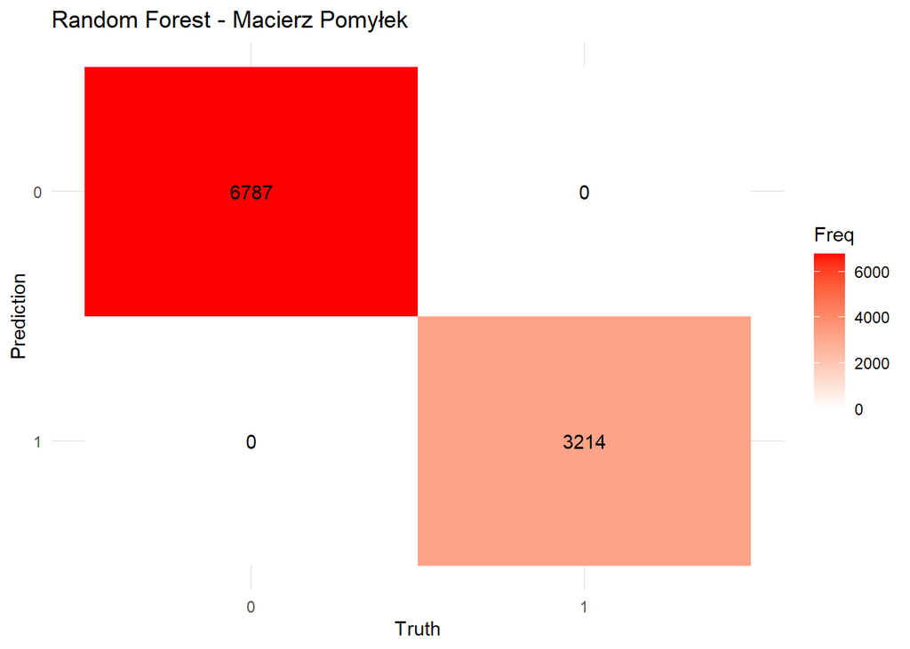

### Wnioski z macierzy pomyłek

- **True Negatives (TN = 6787)**: Model idealnie rozróżnia przypadki, w których nie zachodzi kradzież środków – poprawnie sklasyfikowano wszystkie transakcje.
- **False Positives (FP = 0)**: Model się nie myli.
- **False Negatives (FN = 0)**: Model się nie myli.
- **True Positives (TP = 3214)**: Model idealnie rozpoznaje przypadki, w których zachodzi kradzież środków – poprawnie sklasyfikowano wszystkie oszustwa.

# Porównanie metod balansowania dla Random Forest

Random Forest: Porównanie metod balansowania

Trening i test – metryki klasyfikacji

| Method | Recall_Train | F1_Score_Train | Precision_Train | Accuracy_Train | Recall_Test | F1_Score_Test | Precision_Test | Accuracy_Test |
| --- | --- | --- | --- | --- | --- | --- | --- | --- |
| Brak balansowania | 1.00 | 1.00 | 1.00 | 1.00 | 1.00 | 1.00 | 1.00 | 1.00 |
| SMOTE | 1.00 | 1.00 | 1.00 | 1.00 | 1.00 | 1.00 | 1.00 | 1.00 |
| OverSampling | 1.00 | 1.00 | 1.00 | 1.00 | 1.00 | 1.00 | 1.00 | 1.00 |
| UnderSampling | 1.00 | 1.00 | 1.00 | 1.00 | 1.00 | 1.00 | 1.00 | 1.00 |

W celu zbadania wpływu różnych metod balansowania zbioru danych na jakość klasyfikacji przeprowadzono trening modelu **Random Forest** przy zastosowaniu następujących podejść:

1. **Brak balansowania (Baseline)**
2. **SMOTE (Synthetic Minority Over-sampling Technique)**
3. **Random OverSampling (losowe nadpróbkowanie klasy mniejszościowej)**
4. **Random UnderSampling (losowe usunięcie próbek z klasy większościowej)**

### Opis metod balansowania

- **Brak balansowania**:  
  Dane treningowe wykorzystano w oryginalnej, niezbalansowanej postaci. Model Random Forest potrafi radzić sobie z lekką niezbalansowanością dzięki losowemu doborowi próbek i podziałów w drzewach.
- **SMOTE (Synthetic Minority Over-sampling Technique)**:  
  Technika syntetycznego generowania nowych przykładów klasy mniejszościowej poprzez interpolację istniejących przypadków. Celem jest zredukowanie problemu niezbalansowania bez utraty informacji.
- **Random OverSampling**:  
  Proste losowe powielanie istniejących próbek klasy mniejszościowej aż do wyrównania liczby przypadków obu klas.
- **Random UnderSampling**:  
  Losowe usunięcie obserwacji z klasy większościowej, aby dopasować liczebność do klasy mniejszościowej. Może prowadzić do utraty informacji z danych.

### Analiza wyników

Niezależnie od zastosowanej metody balansowania model Random Forest osiągnął **identyczne, perfekcyjne wyniki (Recall = Precision = F1 = Accuracy = 1.00)** zarówno na zbiorze treningowym, jak i testowym.

### Możliwe przyczyny takiego rezultatu:

1. **Wyjątkowa moc modelu Random Forest**:
   - Model ten jest bardzo odporny na niezbalansowane zbiory dzięki budowie wielu drzew decyzyjnych na losowych próbkach.
2. **Charakterystyka danych**:
   - Zmienna objaśniana jest dość dobrze rozróżnialna na podstawie dostępnych zmiennych predykcyjnych (np. `Risk_Score`, `Failed_Transaction_Count_7d`), co ułatwia klasyfikację niezależnie od balansu danych.
3. **Mały stopień niezbalansowania zbioru**:
   - Stosunek klas (ok. 1:2) nie jest bardzo skrajny — model mógł poradzić sobie z oryginalną dystrybucją bez potrzeby korekty.
4. **Potencjalny overfitting (przeuczenie)**:
   - Idealne wyniki mogą świadczyć o nadmiernym dopasowaniu modelu do danych treningowych i testowych — może to wynikać z małego zbioru danych lub podobnej struktury zbioru testowego i treningowego.

# Podsumowanie i wnioski końcowe

### Wnioski końcowe:

- **Random Forest** okazał się najskuteczniejszym algorytmem w wykrywaniu transakcji oszukańczych w analizowanym zbiorze danych. Model ten zapewniał najwyższą wartość recall, precision, F1-score i accuracy zarówno w zbiorze treningowym, jak i testowym.
- **Balansowanie zbioru danych nie wpłynęło znacząco na jakość modelu Random Forest**, co może wynikać z niewielkiego stopnia niezbalansowania danych oraz dużej mocy predykcyjnej wybranych zmiennych.
- Najważniejsze zmienne wpływające na wykrywanie fraudów to: **Failed_Transaction_Count_7d** oraz **Risk_Score**, co potwierdzono zarówno analizą rozkładów tych cech względem Fraud_Label, jak i wynikami Mutual Information.
- Przeprowadzona analiza potwierdza, że dobrze dobrane cechy oraz zastosowanie modelu Random Forest umożliwia skuteczne wykrywanie oszustw finansowych w transakcjach elektronicznych.